# Система pH. Фильтрация алгоритмами UKF и PF(boot).

Горбунов Сергей

08 01 2022

# 1.1 Описание системы

Имеется непрерывно-дискретная система наблюдения.
$$dx_1(t) = (\frac{1}{\theta}(x_{1,i} - x_1) - \frac{1}{V}x_1q_B)dt + b_1(t)dw_1(t)$$
$$dx_2(t) = (-\frac{1}{\theta}x_2 + \frac{1}{V}(x_{2,i} - x_2)q_B)dt + b_2(t)dw_2(t)$$
$$dx_3(t) = (-\frac{1}{\theta}x_3 + \frac{1}{V}(x_{3,i} - x_3)q_B)dt + b_3(t)dw_3(t)$$

$$x(0) = (9.484*10^{-4}, 4.194*10^{-4}, 5.242*10^{-4})$$

Вектор состояния системы $x=(x_1,x_2,x_3)$, где $x_1=[A^-]$, $x_2=[B^+]$ и $x_3=[X^-]$ - концентрации кислоты, основания и буфферного раствора соответственно. $w_1(t), w_2(t), w_3(t)$ - стандартные винеровские процессы.

$$y_k = pH + B_kW_k, \ k = 0...2000$$

$\xi = 10^{-pH}$

$\xi^3 + [\frac{K_w}{K_x} + x_3 + x_2 - x_1]\xi^2 + (x_2 - x_1 - K_x)\frac{K_w}{K_x}\xi - \frac{K_w^2}{K_x} = 0$

Введем обозначения для коэффициентов уравнения.

$a = 1$

$b = \frac{K_w}{K_x} + x_3 + x_2 - x_1$

$c = (x_2 - x_1 - K_x)\frac{K_w}{K_x}$

$d = - \frac{K_w^2}{K_x}$

$p = -\frac{b}{3a}$

$q = p^3 + \frac{bc-3ad}{6a^2}$

$r = \frac{c}{3a}$

$$pH = -log_{10}((q + \sqrt{q^2+(r-p^2)^3})^\frac{1}{3} + (q - \sqrt{q^2+(r-p^2)^3})^\frac{1}{3} + p)$$

# 1.2 Параметры системы

$x_{1,i}=1.2*10^{-3} mol/L$ - концентрация кислоты на входе;

$x_{2,i}=2.0*10^{-3} mol/L$ - концентрация основания на входе;

$x_{3,i}=2.5*10^{-3} mol/L$ - концентрация буферного раствора на входе;

$K_x=10^{-7} mol/L$ - константа диссоциации буфферного раствора;

$K_w=10^{-14} mol^2/L^2$ - константа диссоциации воды;

$V = 2.5L$ - объем реактора;

$q_A=1+0.06sin(0.01t)$ - входной поток;

$q_B=0.265L/min$ - скорость потока;

$\theta=\frac{V}{q_A}$;

$b_1(t)=b_2(t)=b_3(t)=\sqrt{2*10^{-11}} mol/L$;

$B_k=10^{-2}, \ k=0...2000$.

# 2. Параметры алгоритмов фильтрации

“Нулевой” вес для построения сигма-точек $w_0 = \frac{1}{4}$, число частиц $N=100$.

# 3. Моделирование системы и оценка состояния

Дискретизуем непрерывное состояние с шагом $h=1$, смоделируем систему и оценим её состояние алгоритмами UKF и PF(boot).

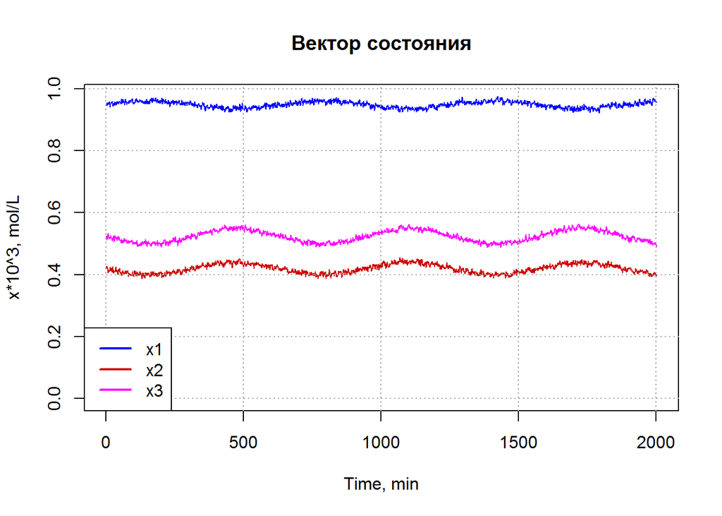

```r
library(mvtnorm)
library(pracma)

x1i <- 1.2e-3
x2i <- 2e-3
x3i <- 2.5e-3
Kx <- 1e-7
Kw <- 1e-14
V <- 2.5
qA <- function(t) { 1+0.06*sin(0.01*t) }
qB <- 0.265
theta <- function(t) { V/qA(t) }
x0 <- c(9.484e-4, 4.194e-4, 5.242e-4)
var_state <- 2e-11
var_obs <- 1e-4
a <- 1
d <- -Kw^2/Kx
T <- 2000

at <- function(x, t)
{
  return(c(x[1] + (x1i - x[1])/theta(t) - x[1]*qB/V,
           x[2] - x[2]/theta(t) + (x2i - x[2])*qB/V,
           x[3] - x[3]/theta(t) + (x3i - x[3])*qB/V))
}
At <- function(x, t)
{
  b <- Kw/Kx + x[3] + x[2] - x[1]
  c <- (x[2] - x[1] - Kx)*Kw/Kx
  p <- -b/(3*a)
  q <- p^3 + (b*c - 3*a*d)/(6*a^2)
  r <- c/(3*a)
  return(Re(-log10((q + sqrt(as.complex(q^2 + (r-p^2)^3)))^(1/3) + (q - sqrt(as.complex(q^2 + (r-p^2)^3)))^(1/3) + p)))
}
bt <- diag(rep(sqrt(var_state), length(x0)))
Bt <- sqrt(var_obs)

pH_system <- function(x0, at, At, bt, Bt, T)
{
  sys <- matrix(NA, nrow = T+1, ncol = 4)
  colnames(sys) <- c('x1', 'x2', 'x3', 'pH')
  sys[1,1:3] <- x0
  U <- cbind(rnorm(T+1), rnorm(T+1), rnorm(T+1))
  W <- rnorm(T+1)
  for(i in 1:(T+1)){
    sys[i,4] <- At(sys[i,1:3], t) + Bt*W[i]
    if(i != T+1){
      sys[i+1,1:3] <- at(sys[i,1:3], i+1) + bt%*%U[i+1, ]
    }
  }
  return(sys)
}

set.seed(1)
sys <- pH_system(x0, at, At, bt, Bt, T)

# State Vector Plot
plot(sys[ ,'x1']*10^3, type = 'l', ylim = c(0, max(sys[ ,1:3])*10^3), col = 'blue',
     xlab = 'Time, min', ylab = 'x*10^3, mol/L', main = 'Вектор состояния')
lines(sys[ ,'x2']*10^3, col = 'red3')
lines(sys[ ,'x3']*10^3, col = 'magenta')
abline(h = seq(0, 1, by = 0.2), col = 'darkgray', lty = 'dotted')
abline(v = seq(0, 2000, by = 500), col = 'darkgray', lty = 'dotted')
legend('bottomleft', c('x1', 'x2', 'x3'), col = c('blue', 'red3', 'magenta'), lwd = 2)
```

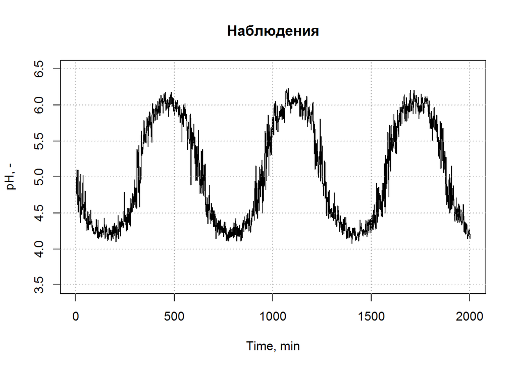

```r
# pH Plot
plot(sys[,'pH'], type = 'l', ylim = c(3.5, 6.5), xlab = 'Time, min', ylab = 'pH, -',
     main = 'Наблюдения')
abline(h = seq(3.5, 6.5, by = 0.5), col = 'darkgray', lty = 'dotted')
abline(v = seq(0, 2000, by = 500), col = 'darkgray', lty = 'dotted')
```

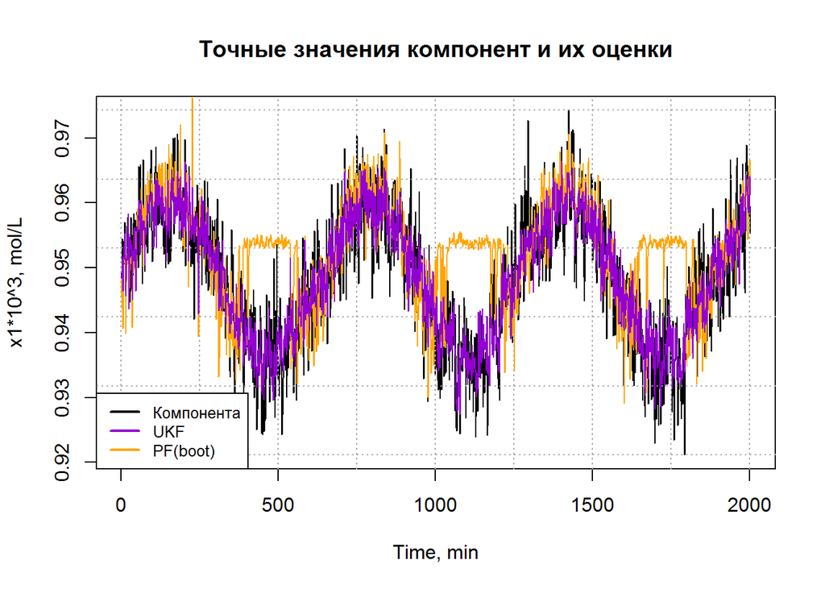

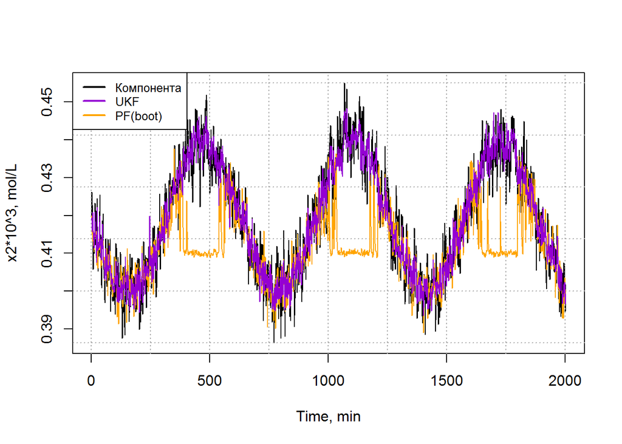

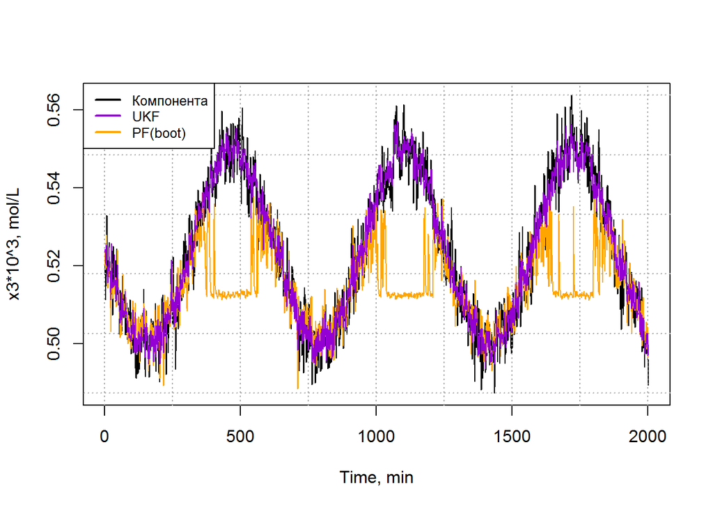

```r
discrete <- function(Value, Prob)
{
  r <- runif(1)
  for(i in 1:length(Prob)){
    if(i == 1){
      if(r < Prob[1])
        return(Value[1, ])
    }else{
      if(r > sum(Prob[1:(i-1)]) & r < sum(Prob[1:i]))
        return(Value[i, ])
    }
  }
}
# Unscented Kalman Filter
sigmaPoints <- function(k, x, w0)
{
  N <- length(x)
  res <- matrix(NA, nrow = 2*N + 1, ncol = N + 1)
  res[2*N+1, ] <- c(x, w0)
  res[1:(2*N),N+1] <- rep((1-w0)/(2*N), 2*N)
  ch <- t(chol(k*N/(1-w0)))
  for(i in 1:N){
    res[i,1:N] <- x + ch[ ,i]
    res[N+i,1:N] <- x - ch[ ,i]
  }
  return(res)
}

UKF <- function(at, bt, At, Bt, m0, Y, w0)
{
  T <- length(Y)
  N <- length(m0)
  X_us <- matrix(NA, nrow = T, ncol = N)
  X_us[1, ] <- m0
  k <- eye(N)*var_state
  for(i in 1:(T-1)){
    sp <- sigmaPoints(k, X_us[i,], w0)
    Q <- dim(sp)[1]
    X_moon <- apply(sapply(1:Q, function(j) sp[j,N+1]*at(sp[j,1:N],i+1)), 1, FUN = sum)
    k_moon <- zeros(N)
    for(j in 1:Q)
      k_moon <- k_moon + sp[j,N+1]*(at(sp[j,1:N],i+1) - X_moon)%*%t(at(sp[j,1:N],i+1) - X_moon)
    k_moon <- k_moon + bt%*%t(bt)
    sp <- sigmaPoints(k_moon, X_moon, w0)
    Y_moon <- sum(sapply(1:Q, function(j) sp[j,N+1]*At(sp[j,1:N],i+1)))
    kappa_moon <- sum(sapply(1:Q, function(j) sp[j,N+1]*(At(sp[j,1:N],i+1) - Y_moon)^2))
    kappa_moon <- kappa_moon + Bt^2
    mu_moon <- apply(sapply(1:Q, function(j) sp[j,N+1]*(sp[j,1:N] - X_moon)*(At(sp[j,1:N],i+1) - Y_moon)), 1, FUN = sum)
    X_us[i+1, ] <- X_moon + mu_moon*kappa_moon^(-1)*(Y[i+1] - Y_moon)
    k <- k_moon - kappa_moon^(-1)*mu_moon%*%t(mu_moon)
  }
  return(X_us)
}

#Bootstrap Particle Filter
bootstrapFilter <- function(at, bt, At, Bt, m0, Y, N)
{
  T <- length(Y)
  X_hat <- matrix(NA, nrow = T, ncol = 3)
  X <- matrix(rep(m0, N), nrow = N, byrow = TRUE)
  w <- rep(1/N, N)
  X_hat[1, ] <- m0
  for(i in 2:T){
    X <- t(sapply(1:N, function(j) rmvnorm(1, mean = at(X[j, ],j), sigma = bt%*%bt)))
    w_prev <- w
    w <- sapply(1:N, function(j) (dnorm(Y[i], mean = At(X[j, ],j), sd = Bt)/Bt)*w_prev[j])
    if(sum(w^2) == 0){
      w <- rep(1/N, N)
    }
    w <- w/sum(w)
    if(1/sum(w^2) < N/10){
      X <- t(sapply(1:N, function(j) discrete(X,w)))
      w <- rep(1/N, N)
    }
    X_hat[i, ] <- apply(sapply(1:N, function(j) w[j]*X[j, ]), 1, FUN = sum)
  }
  return(X_hat)
}

m0 <- x0
N <- 100
set.seed(1)
ukf <- UKF(at, bt, At, Bt, m0, Y = sys[,'pH'], w0 = 1/4)
bf <- bootstrapFilter(at, bt, At, Bt, m0, Y = sys[ ,'pH'], N)

# Results
name = 'Точные значения компонент и их оценки'
pos = 'bottomleft'
for(i in 1:3){
  plot(sys[ ,i]*1e3, type = 'l', xlab = 'Time, min', ylab = paste0('x',i,'*10^3, mol/L'), main = name)
  abline(h = seq(min(sys[ ,i]*1e3), max(sys[ ,i]*1e3), length.out = 6), col = 'darkgray', lty = 'dotted')
  abline(v = seq(0, 2000, by = 250), col = 'darkgray', lty = 'dotted')
  name = ''
  lines(bf[ ,i]*1e3, col = 'orange')
  lines(ukf[ ,i]*1e3, col = 'darkviolet')
  legend(pos, c('Компонента', 'UKF', 'PF(boot)'), col = c('black', 'darkviolet', 'orange'), lwd = 2, cex = 0.8)
  pos = 'topleft'
}
```

Легко заметить, что PF(boot) “ломается” в точках, близких к локальным минимумам функции qA.

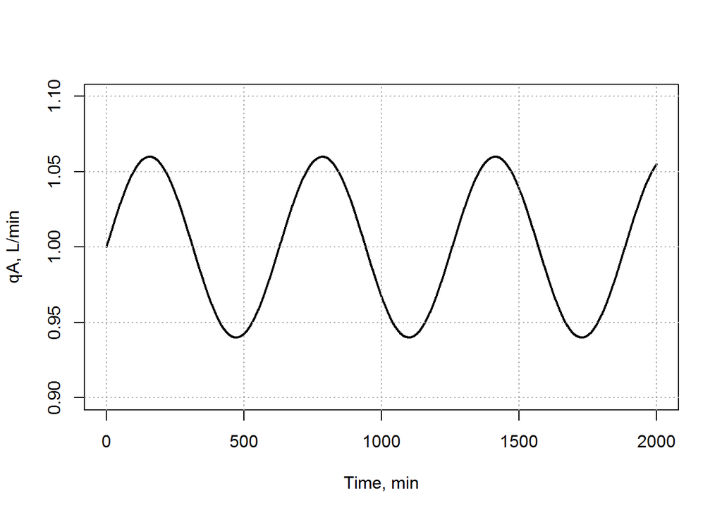

```r
# qA Plot
plot(0:2000, qA(0:2000), type = 'l', ylim = c(0.9, 1.1), lwd = 2,
     xlab = 'Time, min', ylab = 'qA, L/min')
abline(h = seq(0.9, 1.1, by = 0.05), col = 'darkgray', lty = 'dotted')
abline(v = seq(0, 2000, by = 500), col = 'darkgray', lty = 'dotted')
```

Интересно, что если в формуле $q_A=1+0.06sin(0.01t)$ константное слагаемое немного увеличить или уменьшить, ситуация с PF(boot) станет гораздо лучше. Для примера изменим формулу на $q_A=0.9+0.06sin(0.01t)$, а после вернем исходное значение.

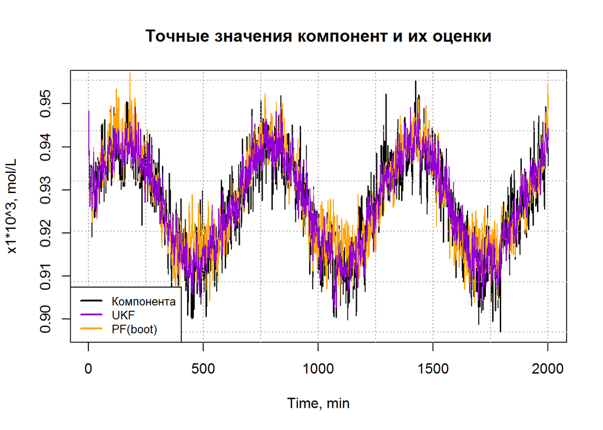

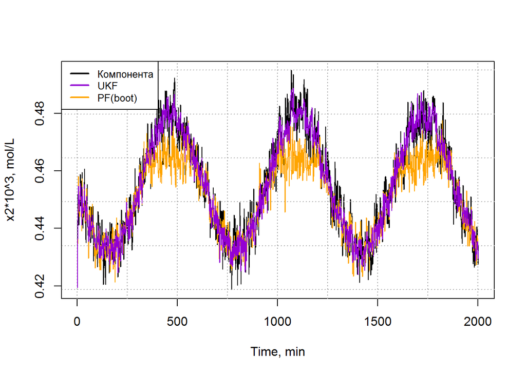

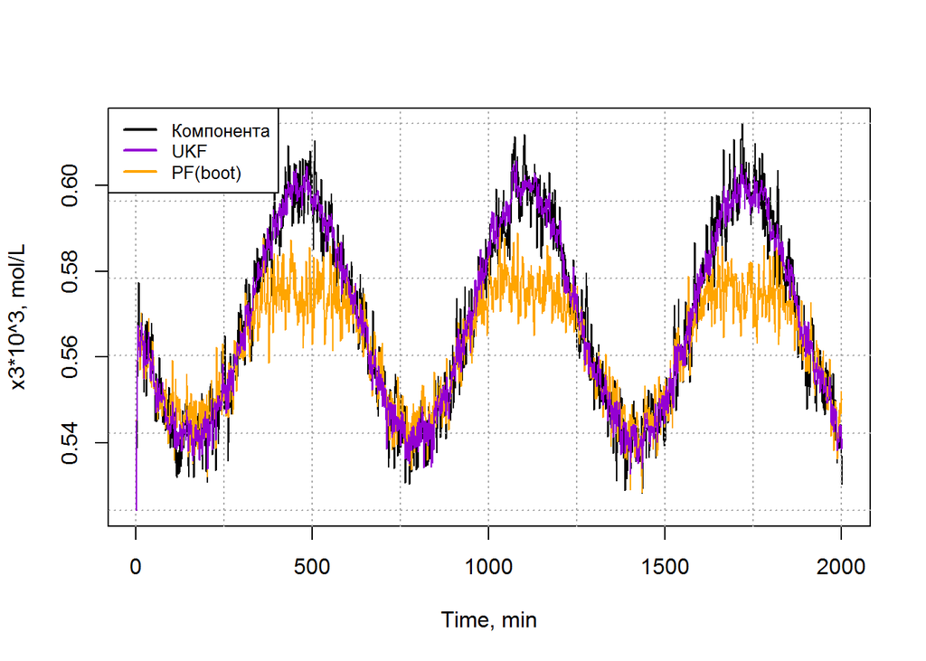

```r
qA <- function(t) { 0.9+0.06*sin(0.01*t) }
set.seed(1)
sys <- pH_system(x0, at, At, bt, Bt, T)
ukf <- UKF(at, bt, At, Bt, m0, Y = sys[,'pH'], w0 = 1/4)
bf <- bootstrapFilter(at, bt, At, Bt, m0, Y = sys[ ,'pH'], N)

name = 'Точные значения компонент и их оценки'
pos = 'bottomleft'
for(i in 1:3){
  plot(sys[ ,i]*1e3, type = 'l', xlab = 'Time, min', ylab = paste0('x',i,'*10^3, mol/L'), main = name)
  abline(h = seq(min(sys[ ,i]*1e3), max(sys[ ,i]*1e3), length.out = 6), col = 'darkgray', lty = 'dotted')
  abline(v = seq(0, 2000, by = 250), col = 'darkgray', lty = 'dotted')
  name = ''
  lines(bf[ ,i]*1e3, col = 'orange')
  lines(ukf[ ,i]*1e3, col = 'darkviolet')
  legend(pos, c('Компонента', 'UKF', 'PF(boot)'), col = c('black', 'darkviolet', 'orange'), lwd = 2, cex = 0.8)
  pos = 'topleft'
}
```

```r
qA <- function(t) { 1+0.06*sin(0.01*t) }
```

# 4. Выборочное СКО компонент и ошибок оценки

Следующий фрагмент программы генерирует n_samp траекторий, оценивает состояния алгоритмами UKF и PF(boot), считает ошибку оценки, вычисляет выборочное СКО и сохраняет результаты в соответсвующие файлы.

```r
calculateError <- function(at, bt, At, Bt, x0, T, w0, N)
{
  sys <- pH_system(x0, at, At, bt, Bt, T)
  ukf <- UKF(at, bt, At, Bt, m0 = x0, Y = sys[,'pH'], w0 = 1/4)
  bf <- bootstrapFilter(at, bt, At, Bt, m0 = x0, Y = sys[ ,'pH'], N)
  return(cbind(sys[ ,1:3] - ukf, sys[ ,1:3] - bf, sys[ ,1:3]))
}
w0 <- 1/4
N <- 100
n_samp <- 1000
x1_u <- matrix(NA, nrow = T+1, ncol = n_samp)
x2_u <- matrix(NA, nrow = T+1, ncol = n_samp)
x3_u <- matrix(NA, nrow = T+1, ncol = n_samp)
x1_b <- matrix(NA, nrow = T+1, ncol = n_samp)
x2_b <- matrix(NA, nrow = T+1, ncol = n_samp)
x3_b <- matrix(NA, nrow = T+1, ncol = n_samp)
x1 <- matrix(NA, nrow = T+1, ncol = n_samp)
x2 <- matrix(NA, nrow = T+1, ncol = n_samp)
x3 <- matrix(NA, nrow = T+1, ncol = n_samp)
for(i in 1:n_samp){
  err <- calculateError(at, bt, At, Bt, x0, T, w0, N)
  x1_u[ ,i] <- err[ ,1]
  x2_u[ ,i] <- err[ ,2]
  x3_u[ ,i] <- err[ ,3]
  x1_b[ ,i] <- err[ ,4]
  x2_b[ ,i] <- err[ ,5]
  x3_b[ ,i] <- err[ ,6]
  x1[ ,i] <- err[ ,7]
  x2[ ,i] <- err[ ,8]
  x3[ ,i] <- err[ ,9]
}
comp_rmse <- cbind(apply(x1, 1, FUN = sd), apply(x2, 1, FUN = sd), apply(x3, 1, FUN = sd))
ukf_rmse <- cbind(apply(x1_u, 1, FUN = sd), apply(x2_u, 1, FUN = sd), apply(x3_u, 1, FUN = sd))
bf_rmse <- cbind(apply(x1_b, 1, FUN = sd), apply(x2_b, 1, FUN = sd), apply(x3_b, 1, FUN = sd))
colnames(comp_rmse) <- c('x1', 'x2', 'x3')
colnames(ukf_rmse) <- c('x1', 'x2', 'x3')
colnames(bf_rmse) <- c('x1', 'x2', 'x3')
write.csv(comp_rmse, 'comp_rmse.csv', row.names = FALSE)
write.csv(ukf_rmse, 'ukf_rmse.csv', row.names = FALSE)
write.csv(bf_rmse, 'bf_rmse.csv', row.names = FALSE)
```

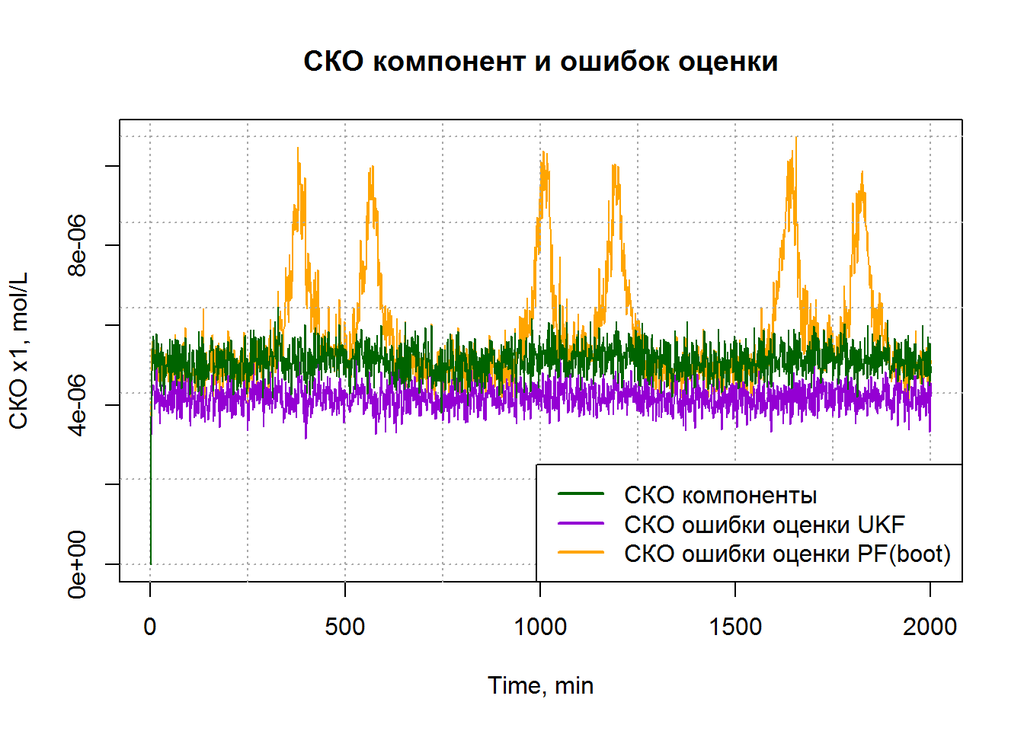

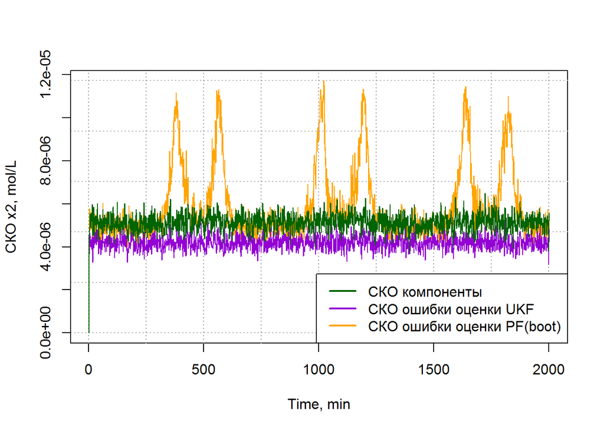

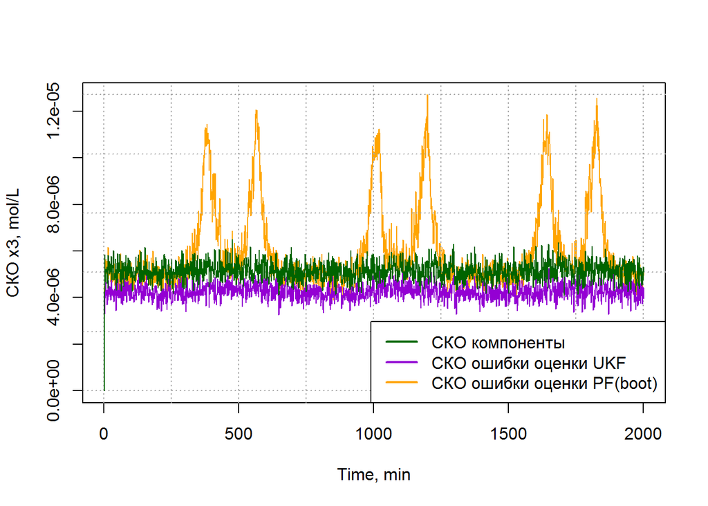

```r
comp_rmse <- read.csv('comp_rmse.csv')
ukf_rmse <- read.csv('ukf_rmse.csv')
bf_rmse <- read.csv('bf_rmse.csv')
name = 'СКО компонент и ошибок оценки'
for(i in 1:3){
  plot(bf_rmse[ ,i], type = 'l', col = 'orange', xlab = 'Time, min', ylab = paste0('СКО x', i, ', mol/L'), main = name)
  abline(h = seq(0, max(bf_rmse[ ,i]), length.out = 6), col = 'darkgray', lty = 'dotted')
  abline(v = seq(0, 2000, by = 250), col = 'darkgray', lty = 'dotted')
  name = ''
  lines(ukf_rmse[ ,i], col = 'darkviolet')
  lines(comp_rmse[ ,i], col = 'darkgreen')
  legend('bottomright', c('СКО компоненты', 'СКО ошибки оценки UKF', 'СКО ошибки оценки PF(boot)'), col = c('darkgreen', 'darkviolet', 'orange'), lwd = 2)
}
```